# Fast Fourier Transform FFT

### **NOTES ON STATISTICS, PROBABILITY and MATHEMATICS**

### Fast Fourier Transform (FFT):

In the decimation in time FFT a big DFT is build from smaller ones. The assumption is $N = 2^m$ with $N$ being the number of sampled points. The sampled points (in the time domain), i.e. $x[n]$ are separate into even and odd-indexed sequences. $k$ corresponds to the harmonic number or frequency parameter:

Remembering that $\large\color{blue}{\large W_N \equiv e^{-i\frac{2\pi}{N}}}$ corresponds to the *twiddle factor*:

$$\large
X[k]=\sum_{n=0}^{N-1}\,x[n]\,W_N^{kn}=\sum_{n\text{
even}}\,x[n]\,W_N^{kr}\,+\,\sum_{n\text{
odd}}\,x[n]\,W_N^{kr}$$

where $n = 2r$ for even indices, and $n = 2r +1$ for odd indices, and $r = 0,1,\cdots,\frac{N}{2}-1.$

So we can re-write the eqution as:

$$\large\begin{align}\large
X[k]&=\sum_{r=0}^{\frac{N}{2}-1}\,x[2r]\,W_N^{k2r} +
\sum_{r=0}^{\frac{N}{2}-1}\,x[2r+1]\,W_N^{k(2r+1)}\\[2ex]\
&= \sum_{r=0}^{\frac{N}{2}-1}\,x[2r]\,W_N^{k2r} +
\sum_{r=0}^{\frac{N}{2}-1}\,x[2r+1]\,W_N^{k}W_N^{k2r}\\[2ex]
&=\sum_{r=0}^{\frac{N}{2}-1}\,x[2r]\,W_N^{k2r} +W_N^{k}
\sum_{r=0}^{\frac{N}{2}-1}\,x[2r+1]\,W_N^{k2r}\\[2ex]
&=\sum_{r=0}^{\frac{N}{2}-1}\,x[2r]\,(W_N^2)^{kr} +W_N^{k}
\sum_{r=0}^{\frac{N}{2}-1}\,x[2r+1]\,(W_N^2)^{kr}\\[2ex]
&\underset{*}= \sum_{r=0}^{\frac{N}{2}-1}\,x[2r]\,W_{N/2}^{kr}
+W_N^{k} \sum_{r=0}^{\frac{N}{2}-1}\,x[2r+1]\,W_{N/2}^{kr}\\[2ex]
&\underset{**}= X_e[k] + W_N^k\,X_o[k]
\end{align}$$

$*$ because $\color{blue}{W_N^2=e^{-i\frac{2\dot2\pi}{N}}=e^{-i\frac{2\pi}{N/2}}=W_{N/2}}$

$**$ the sum of two $N/2$ point DFTs.

But $k$ runs from 0 to $N-1$ while there are only $N/2$ odd numbers and $N/2$ even numbers. So how can it be… Let’s try with an $8$-point DFT:

For $k=0$:

$$\begin{align}X[0]&=\sum_{r=0}^{3}\,x[2r]\,W_{4}^{0r}
+W_8^{0} \sum_{r=0}^{3}\,x[2r+1]\,W_{4}^{0r}\\[2ex]
&=\sum_{r=0}^{3}\,x[2r] +W_8^{0} \sum_{r=0}^{3}\,x[2r+1]\\[2ex]
&=X_e[0] + X_o[0]
\end{align}$$

For $k=1$:

$$\begin{align}X[1]&=\sum_{r=0}^{3}\,x[2r]\,W_{4}^{1r}
+W_8^{1} \sum_{r=0}^{3}\,x[2r+1]\,W_{4}^{1r}\\[2ex]
&=X_e[1] + W_8^1\,X_o[1]
\end{align}$$

$\vdots$

For $k = 4$, though, this reasoning, runs into a “problem” because summarizing the corresponding expression as a sum of DFT of even and odd numbers, such as

$$\begin{align}X[\color{red}{4}]&\overset{?}=X_e[\color{red}{4}]+W_8^4\,X_o[\color{red}{4}]\tag{1}\\[2ex]
&\overset{?}=\sum_{r=0}^{\color{red}{3}}\,x[2r]\,W_{4}^{\color{red}{4}r}
+W_8^{4} \sum_{r=0}^{\color{red}{3}}\,x[2r+1]\,W_{4}^{\color{red}{4}r}
\end{align}$$

makes apparently no sense, since $k$ in DFT runs from $0,1,2,\cdots,r-1=3$.

However,

$$\large
W_4^{4r}=e^{-i\frac{2\pi}{4}4r}=1=W_{4}^{0r}$$
.

What about $X[5]$… well

$$\begin{align}\large W_4^{5r}
&= e^{-i\frac{2\pi}{4}5r}\\[2ex]
&= e^{-i\frac{2\pi}{4}4r}\,e^{-i\frac{2\pi}{4}r}\\[2ex]
&= e^{-i\frac{2\pi}{4}r}\\[2ex]
&= W_4^{1r}
\end{align}$$

Going back to Eq. $1$:

$$X[\color{red}{5}]=X_e[\color{red}{5}]+W_8^5\,X_o[\color{red}{5}]=X_e[\color{red}{1}]+W_8^5\,X_o[\color{red}{1}]$$

$$X[\color{red}{6}]=X_e[\color{red}{6}]+W_8^6\,X_o[\color{red}{6}]=X_e[\color{red}{2}]+W_8^6\,X_o[\color{red}{2}]$$

$$\begin{align}X[\color{red}{7}]&=X_e[\color{red}{7}]+W_8^7\,X_o[\color{red}{7}]=X_e[\color{red}{3}]+W_8^7\,X_o[\color{red}{3}]\\[2ex]
&=\underset{X_e[3]}{\underbrace{\sum_{r=0}^{\color{red}{3}}\,x[2r]\,W_{\color{blue}{4}}^{\color{red}{3}r}}}
+W_8^{7}
\underset{X_o[3]}{\underbrace{\sum_{r=0}^{\color{red}{3}}\,x[2r+1]\,W_{\color{blue}{4}}^{\color{red}{3}r}}}
\end{align}$$

Explaining the plot in [this youtube video](https://youtu.be/EsJGuI7e_ZQ):

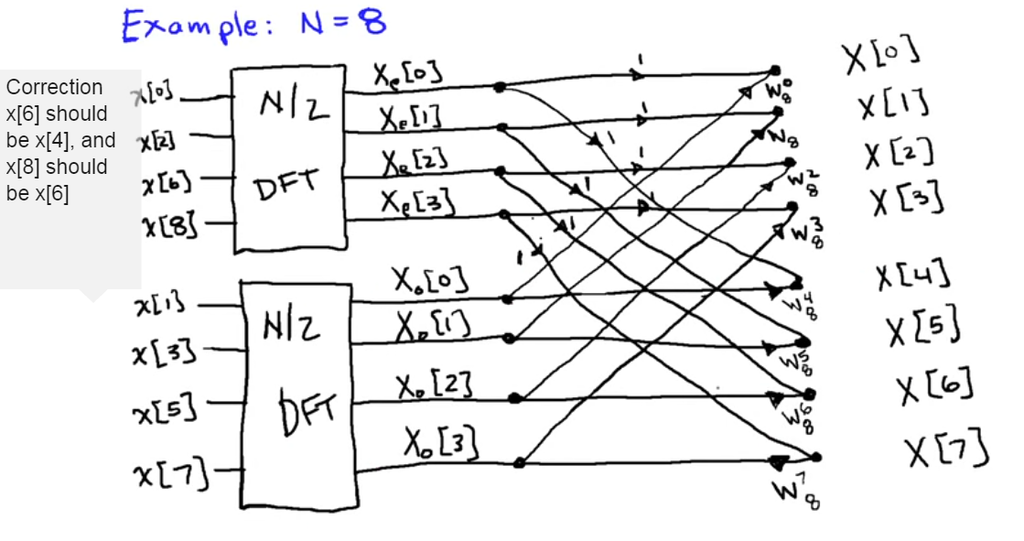

So regularly calculated DFTs take $O( N^2)$, but splitting the $2^N$ signals into even and odd results in $\left(\frac{N}{2}\right)^2\cdot 2$ plus the multiplication by the $W_8$ factors in the example above, resulting in $O\left(\frac{N}{2}\right)^2 +N$

since we started off with a number of the form $2^N$ we can split each $\frac{N}{2}$-point DFTs into $2\frac{N}{4}$-point DFTs:

$$\frac{N}{2},
\frac{N}{4},\cdots,\frac{N}{2^{p-1}}, \frac{N}{2^{p}}$$

where $p = \log_2 N$, such that $\frac{N}{2^{p}}=1$. Hence we end up with a $1$-point DFT at the end. And we’ll end up with $O(N\log_2 N)$ for large $N$.

The resultant idea is:

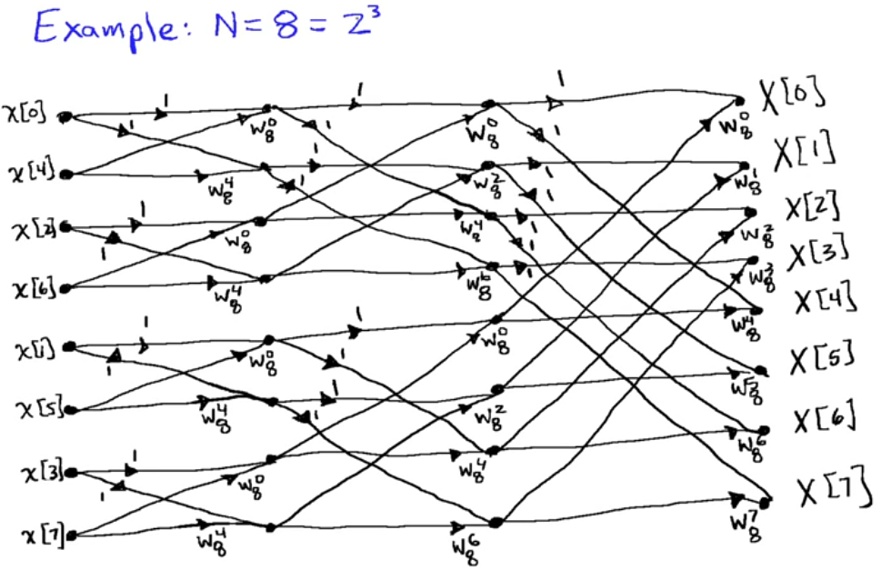

[Home Page](http://rinterested.github.io/statistics/index.html)

**NOTE: These are tentative notes on different topics for personal use - expect mistakes and misunderstandings.**